# ML practice 8. Part 1: Feature Selection

Сегодня мы поговорим о том, какие методы существуют для выбора предикторов для включения в модель.

### Данные

В качестве примера все так же используем данные про цены на жилье в Бостоне

```r
library(MASS)
#?Boston

library(ggplot2)
library(dplyr)
```

- `crim` per capita crime rate by town
- `zn` proportion of residential land zoned for lots over 25,000 sq.ft
- `indus` proportion of non-retail business acres per town
- `chas` Charles River dummy variable (= 1 if tract bounds river; 0 otherwise).
- `nox` nitrogen oxides concentration (parts per 10 million).
- `rm` average number of rooms per dwelling.
- `age` proportion of owner-occupied units built prior to 1940.
- `dis` weighted mean of distances to five Boston employment centres.
- `rad` index of accessibility to radial highways.
- `tax` full-value property-tax rate per $10,000.
- `ptratio` pupil-teacher ratio by town.
- `black` 1000(Bk - 0.63)^2 where Bk is the proportion of blacks by town.
- `lstat` lower status of the population (percent).
- `medv` median value of owner-occupied homes in $1000s.

```r
data(Boston)
pander::pandoc.table(head(Boston), split.tables=Inf)
```

| crim | zn | indus | chas | nox | rm | age | dis | rad | tax | ptratio | black | lstat | medv |
| --- | --- | --- | --- | --- | --- | --- | --- | --- | --- | --- | --- | --- | --- |
| 0.00632 | 18 | 2.31 | 0 | 0.538 | 6.575 | 65.2 | 4.09 | 1 | 296 | 15.3 | 396.9 | 4.98 | 24 |
| 0.02731 | 0 | 7.07 | 0 | 0.469 | 6.421 | 78.9 | 4.967 | 2 | 242 | 17.8 | 396.9 | 9.14 | 21.6 |
| 0.02729 | 0 | 7.07 | 0 | 0.469 | 7.185 | 61.1 | 4.967 | 2 | 242 | 17.8 | 392.8 | 4.03 | 34.7 |
| 0.03237 | 0 | 2.18 | 0 | 0.458 | 6.998 | 45.8 | 6.062 | 3 | 222 | 18.7 | 394.6 | 2.94 | 33.4 |
| 0.06905 | 0 | 2.18 | 0 | 0.458 | 7.147 | 54.2 | 6.062 | 3 | 222 | 18.7 | 396.9 | 5.33 | 36.2 |
| 0.02985 | 0 | 2.18 | 0 | 0.458 | 6.43 | 58.7 | 6.062 | 3 | 222 | 18.7 | 394.1 | 5.21 | 28.7 |

### Обучающая и тестовая выборки

Отделим 20% от датасета. Как обычно, эта часть не будет использоваться для обучения модели, но на ней мы будем проверять (тестировать), насколько хороша наша модель.

```r
set.seed(54321)
Boston.test.ind = sample(seq_len(nrow(Boston)), size = nrow(Boston)*0.2)
Boston.test = Boston[Boston.test.ind,]
Boston.train = Boston[-Boston.test.ind,]
```

## Отбор признаков (Feature Selection)

- Зачем нужно выбирать, какие переменные включить в модель? Почему бы не использовать все?

Некоторые алгоитмы машинного обучения уже построены так, что отбирают только часть признаков. Например, деревья решений

```r
library(partykit)
```

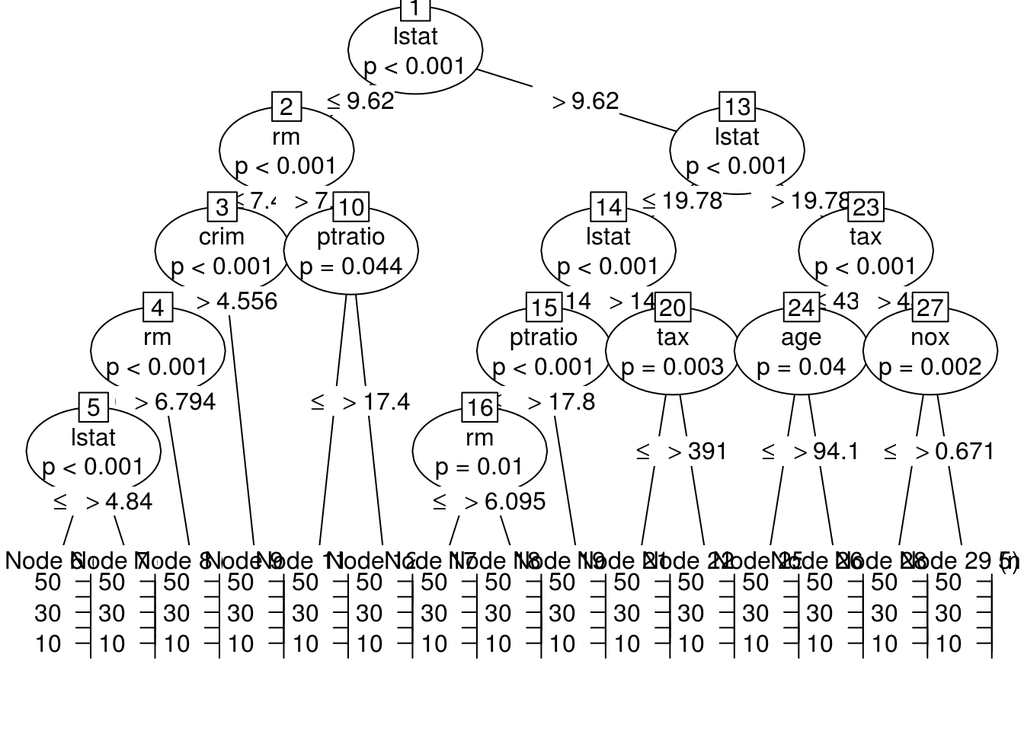

```r
modelTree <- ctree(medv~., data = Boston.train)
plot(modelTree, digits = 3)
```

- Какие переменные не используются в модели?
- Какую долю от общего числа переменных составляют переменные, включенные в итоговую модель?

Другие алгоритмы строят модель по всем доступным переменным. Например:

```r
lm.fit<-lm(medv~., data = Boston.train)
summary(lm.fit)
```

```
##
## Call:
## lm(formula = medv ~ ., data = Boston.train)
##
## Residuals:
##      Min       1Q   Median       3Q      Max
## -15.7438  -2.8338  -0.5712   1.6229  25.6513
##
## Coefficients:
##               Estimate Std. Error t value Pr(>|t|)
## (Intercept)  38.109110   5.894401   6.465 3.02e-10 ***
## crim         -0.112690   0.037720  -2.988  0.00299 **
## zn            0.045050   0.016257   2.771  0.00585 **
## indus        -0.001399   0.070120  -0.020  0.98410
## chas          3.268362   1.003848   3.256  0.00123 **
## nox         -18.243094   4.340659  -4.203 3.27e-05 ***
## rm            3.552151   0.472922   7.511 4.02e-13 ***
## age          -0.005235   0.015474  -0.338  0.73532
## dis          -1.599900   0.234943  -6.810 3.70e-11 ***
## rad           0.307242   0.077514   3.964 8.77e-05 ***
## tax          -0.011755   0.004309  -2.728  0.00666 **
## ptratio      -0.878654   0.155118  -5.664 2.86e-08 ***
## black         0.008669   0.003210   2.701  0.00722 **
## lstat        -0.528347   0.059358  -8.901  < 2e-16 ***
## ---
## Signif. codes:  0 '***' 0.001 '**' 0.01 '*' 0.05 '.' 0.1 ' ' 1
##
## Residual standard error: 5 on 391 degrees of freedom
## Multiple R-squared:  0.7123, Adjusted R-squared:  0.7027
## F-statistic: 74.45 on 13 and 391 DF,  p-value: < 2.2e-16
```

- К какому типу вы отнесете рассмотренные нами ранее алгоритмы (и регрессии, и классификации)?
  - LASSO regression
  - Ridge regression
  - SVM
  - kNN
  - Random Forest
  - Gradient Boosting
  - Logistic regression

### Методы отбора признаков

В целом методы отбора признаков можно разделить на две группы

- добавление / удаление признаков и выбор модели с лучшей оценкой качества (т.е. построение нескольких моделей и сравнение их между собой)
  - Recursive Feature Elimination
  - Genetic Algorithms
  - Simulated Annealing
- оценивание важности каждой из переменных по-отдельности (например, влияния ее на предсказываемую переменную), вне рамок модели

Мы продолжаем использовать пакет `caret` ([подробнее](https://topepo.github.io/caret/feature-selection-overview.html))

```r
library(caret)
```

Посмотрим, есть ли в данных **сильно взаимосвязанные** переменные

```r
correlationMatrix <- cor(Boston)
pander::pandoc.table(correlationMatrix, split.tables=Inf)
```

|  | crim | zn | indus | chas | nox | rm | age | dis | rad | tax | ptratio | black | lstat | medv |
| --- | --- | --- | --- | --- | --- | --- | --- | --- | --- | --- | --- | --- | --- | --- |
| **crim** | 1 | -0.2005 | 0.4066 | -0.05589 | 0.421 | -0.2192 | 0.3527 | -0.3797 | 0.6255 | 0.5828 | 0.2899 | -0.3851 | 0.4556 | -0.3883 |
| **zn** | -0.2005 | 1 | -0.5338 | -0.0427 | -0.5166 | 0.312 | -0.5695 | 0.6644 | -0.3119 | -0.3146 | -0.3917 | 0.1755 | -0.413 | 0.3604 |
| **indus** | 0.4066 | -0.5338 | 1 | 0.06294 | 0.7637 | -0.3917 | 0.6448 | -0.708 | 0.5951 | 0.7208 | 0.3832 | -0.357 | 0.6038 | -0.4837 |
| **chas** | -0.05589 | -0.0427 | 0.06294 | 1 | 0.0912 | 0.09125 | 0.08652 | -0.09918 | -0.007368 | -0.03559 | -0.1215 | 0.04879 | -0.05393 | 0.1753 |
| **nox** | 0.421 | -0.5166 | 0.7637 | 0.0912 | 1 | -0.3022 | 0.7315 | -0.7692 | 0.6114 | 0.668 | 0.1889 | -0.3801 | 0.5909 | -0.4273 |
| **rm** | -0.2192 | 0.312 | -0.3917 | 0.09125 | -0.3022 | 1 | -0.2403 | 0.2052 | -0.2098 | -0.292 | -0.3555 | 0.1281 | -0.6138 | 0.6954 |
| **age** | 0.3527 | -0.5695 | 0.6448 | 0.08652 | 0.7315 | -0.2403 | 1 | -0.7479 | 0.456 | 0.5065 | 0.2615 | -0.2735 | 0.6023 | -0.377 |
| **dis** | -0.3797 | 0.6644 | -0.708 | -0.09918 | -0.7692 | 0.2052 | -0.7479 | 1 | -0.4946 | -0.5344 | -0.2325 | 0.2915 | -0.497 | 0.2499 |
| **rad** | 0.6255 | -0.3119 | 0.5951 | -0.007368 | 0.6114 | -0.2098 | 0.456 | -0.4946 | 1 | 0.9102 | 0.4647 | -0.4444 | 0.4887 | -0.3816 |
| **tax** | 0.5828 | -0.3146 | 0.7208 | -0.03559 | 0.668 | -0.292 | 0.5065 | -0.5344 | 0.9102 | 1 | 0.4609 | -0.4418 | 0.544 | -0.4685 |
| **ptratio** | 0.2899 | -0.3917 | 0.3832 | -0.1215 | 0.1889 | -0.3555 | 0.2615 | -0.2325 | 0.4647 | 0.4609 | 1 | -0.1774 | 0.374 | -0.5078 |
| **black** | -0.3851 | 0.1755 | -0.357 | 0.04879 | -0.3801 | 0.1281 | -0.2735 | 0.2915 | -0.4444 | -0.4418 | -0.1774 | 1 | -0.3661 | 0.3335 |
| **lstat** | 0.4556 | -0.413 | 0.6038 | -0.05393 | 0.5909 | -0.6138 | 0.6023 | -0.497 | 0.4887 | 0.544 | 0.374 | -0.3661 | 1 | -0.7377 |
| **medv** | -0.3883 | 0.3604 | -0.4837 | 0.1753 | -0.4273 | 0.6954 | -0.377 | 0.2499 | -0.3816 | -0.4685 | -0.5078 | 0.3335 | -0.7377 | 1 |

```r
highlyCorrelated <- findCorrelation(correlationMatrix, cutoff=0.75)
# print indexes of highly correlated attributes
highlyCorrelated
```

```
## [1]  3 10  5
```

```r
names(Boston)[highlyCorrelated]
```

```
## [1] "indus" "tax"   "nox"
```

Оценим **значимость** признаков согласно модели (например, для линейной регрессии по всем переменным)

```r
model <- train(medv~., data=Boston.train, method="lm")
importance <- varImp(model, scale=FALSE)
print(importance)
```

```
## lm variable importance
##
##         Overall
## lstat   8.90099
## rm      7.51107
## dis     6.80974
## ptratio 5.66441
## nox     4.20284
## rad     3.96369
## chas    3.25584
## crim    2.98755
## zn      2.77119
## tax     2.72813
## black   2.70085
## age     0.33830
## indus   0.01995
```

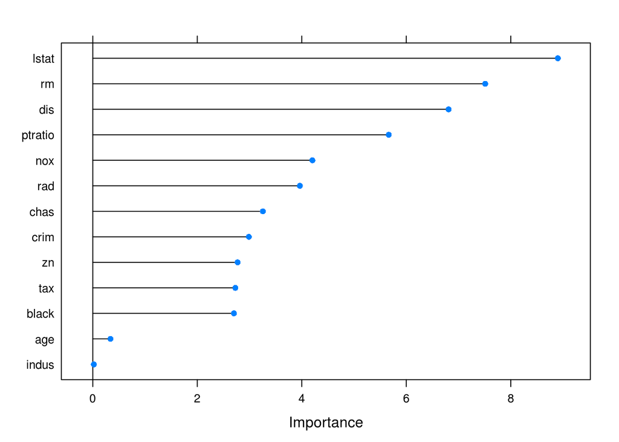

```r
plot(importance)
```

Для разных моделей значимость признаков оценивается по-разному. Для линейной регрессии значимость признака – это модуль значения t-критерия. Подробнее для других моделей можно посмотреть в справке функции `varImp()`

- Какая переменная наиболее значима?

### Recursive Feature Elimination (RFE)

Алгоритм RFE работает следующим образом:

1. Построение модели по всем переменным (признакам)
2. Вычисление оценки качества модели
3. Упорядочение переменных согласно их значимости для модели
4. Удаление наименее значимой переменной
5. Построение модели по новому (сокращенному) набору переменных. Повторение шагов 2-4
6. Выбор лучшей модели (и лучшего набора признаков соответственно)

Как обычно, чтобы избежать переобучения и “подгонки” модели под обучающую выборку, используем кросс-валидацию.

Зададим параметры кросс-валидации

```r
control <- rfeControl(functions=lmFuncs, method="cv", number=10)
```

Запустим алгоритм RFE

```r
set.seed(10)
results <- rfe(x = dplyr::select(Boston.train, -medv),
               y= Boston.train$medv,
               sizes=c(1:13),
               rfeControl=control)
```

Результат:

```r
results
```

```
##
## Recursive feature selection
##
## Outer resampling method: Cross-Validated (10 fold)
##
## Resampling performance over subset size:
##
##  Variables  RMSE Rsquared   MAE RMSESD RsquaredSD  MAESD Selected
##          1 8.297   0.1909 5.947 1.1127     0.0926 0.6783
##          2 7.401   0.3532 5.087 1.0713     0.1952 0.7829
##          3 6.376   0.5226 4.387 1.0402     0.1646 0.4628
##          4 6.343   0.5265 4.357 0.9691     0.1518 0.4759
##          5 5.853   0.5952 4.000 1.1679     0.1740 0.5181
##          6 5.226   0.6783 3.675 0.8433     0.1253 0.4086
##          7 5.220   0.6785 3.705 0.8244     0.1207 0.4254
##          8 5.182   0.6850 3.657 0.7997     0.1157 0.4035
##          9 5.163   0.6867 3.630 0.7614     0.1108 0.3840
##         10 5.156   0.6875 3.630 0.7939     0.1126 0.3835
##         11 5.148   0.6888 3.610 0.8068     0.1118 0.4039
##         12 5.103   0.6945 3.575 0.8263     0.1139 0.4304
##         13 5.088   0.6958 3.560 0.8492     0.1154 0.4555        *
##
## The top 5 variables (out of 13):
##    nox, rm, chas, dis, ptratio
```

Сравнение моделей:

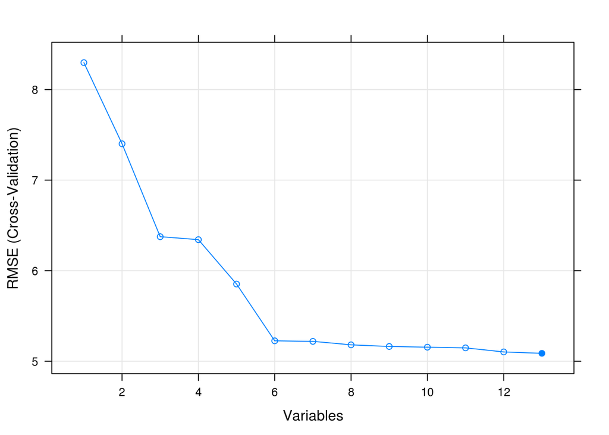

```r
plot(results, type=c("g", "o"))
```

Итоговые предикторы:

```r
predictors(results)
```

```
##  [1] "nox"     "rm"      "chas"    "dis"     "ptratio" "lstat"   "rad"
##  [8] "crim"    "zn"      "indus"   "tax"     "age"     "black"
```

Итоговая модель:

```r
summary(results$fit)
```

```
##
## Call:
## lm(formula = y ~ ., data = tmp)
##
## Residuals:
##      Min       1Q   Median       3Q      Max
## -15.7438  -2.8338  -0.5712   1.6229  25.6513
##
## Coefficients:
##               Estimate Std. Error t value Pr(>|t|)
## (Intercept)  38.109110   5.894401   6.465 3.02e-10 ***
## nox         -18.243094   4.340659  -4.203 3.27e-05 ***
## rm            3.552151   0.472922   7.511 4.02e-13 ***
## chas          3.268362   1.003848   3.256  0.00123 **
## dis          -1.599900   0.234943  -6.810 3.70e-11 ***
## ptratio      -0.878654   0.155118  -5.664 2.86e-08 ***
## lstat        -0.528347   0.059358  -8.901  < 2e-16 ***
## rad           0.307242   0.077514   3.964 8.77e-05 ***
## crim         -0.112690   0.037720  -2.988  0.00299 **
## zn            0.045050   0.016257   2.771  0.00585 **
## indus        -0.001399   0.070120  -0.020  0.98410
## tax          -0.011755   0.004309  -2.728  0.00666 **
## age          -0.005235   0.015474  -0.338  0.73532
## black         0.008669   0.003210   2.701  0.00722 **
## ---
## Signif. codes:  0 '***' 0.001 '**' 0.01 '*' 0.05 '.' 0.1 ' ' 1
##
## Residual standard error: 5 on 391 degrees of freedom
## Multiple R-squared:  0.7123, Adjusted R-squared:  0.7027
## F-statistic: 74.45 on 13 and 391 DF,  p-value: < 2.2e-16
```

Ошибка

```r
lmSelected.test.RSS <- sum((predict(results$fit, Boston.test)-Boston.test$medv)^2)
lmSelected.test.RSS
```

```
## [1] 1358.591
```

Сравним с другими методами:

```r
library(glmnet)

# transform model and data to matrix for glmnet package
X.train <- model.matrix(medv~.-1, data=Boston.train)
X.test <- model.matrix(medv~.-1, data=Boston.test)

# train models
ridge<-cv.glmnet(X.train, Boston.train$medv, alpha = 0)
lss<-cv.glmnet(X.train, Boston.train$medv, alpha = 1)
elastic<-cv.glmnet(X.train, Boston.train$medv, alpha = 0.5)

# calculate errors (test set)
ridge.test.RSS<-sum((predict(ridge,X.test)-Boston.test$medv)^2)
elastic.test.RSS<-sum((predict(elastic,X.test)-Boston.test$medv)^2)
lasso.test.RSS<-sum((predict(lss,X.test)-Boston.test$medv)^2)
lm.test.RSS <- sum((predict(lm.fit, Boston.test)-Boston.test$medv)^2)
tree.test.RSS <- sum((predict(modelTree, Boston.test)-Boston.test$medv)^2)
```

По ошибкам мы получили:

| Метод | RSS (test set) |
| --- | --- |
| LM | 1358.5913921 |
| LM with FS | 1358.5913921 |
| LASSO | 1582.9894192 |
| Ridge | 1901.982546 |
| Elastic 0.5 | 1737.0742919 |
| Tree | 1206.8200133 |

- Какую модель выбрать?

### P.S. Классификация

Выбор признаков применяется не только в задачах регрессии, но и для классификации.

Данные про виды стекла. Оставим только два класса для наглядности:

```r
library(mlbench)
data(Glass)
glass <- Glass %>% filter(Type %in% c(2,1))
glass$Type <- factor(glass$Type)
```

Обучающая и тестовая выборки

```r
set.seed(54321)
glass.test.ind = sample(seq_len(nrow(glass)), size = nrow(glass)*0.4)
glass.test = glass[glass.test.ind,]
glass.main = glass[-glass.test.ind,]
```

Построим модель Random Forrest

```r
library(randomForest)
rf_model <- randomForest(Type ~ ., data=glass.main)
```

Результаты на обучающей

```r
rf.Pred<-predict(rf_model, glass.main, probability=FALSE)
confusionMatrix(rf.Pred,glass.main$Type)
```

```
## Confusion Matrix and Statistics
##
##           Reference
## Prediction  1  2
##          1 44  0
##          2  0 44
##
##                Accuracy : 1
##                  95% CI : (0.9589, 1)
##     No Information Rate : 0.5
##     P-Value [Acc > NIR] : < 2.2e-16
##
##                   Kappa : 1
##  Mcnemar's Test P-Value : NA
##
##             Sensitivity : 1.0
##             Specificity : 1.0
##          Pos Pred Value : 1.0
##          Neg Pred Value : 1.0
##              Prevalence : 0.5
##          Detection Rate : 0.5
##    Detection Prevalence : 0.5
##       Balanced Accuracy : 1.0
##
##        'Positive' Class : 1
##
```

и тестовой выборках

```r
rf.Pred<-predict(rf_model, glass.test, probability=FALSE)
confusionMatrix(rf.Pred,glass.test$Type)
```

```
## Confusion Matrix and Statistics
##
##           Reference
## Prediction  1  2
##          1 25  9
##          2  1 23
##
##                Accuracy : 0.8276
##                  95% CI : (0.7057, 0.9141)
##     No Information Rate : 0.5517
##     P-Value [Acc > NIR] : 9.038e-06
##
##                   Kappa : 0.6612
##  Mcnemar's Test P-Value : 0.02686
##
##             Sensitivity : 0.9615
##             Specificity : 0.7188
##          Pos Pred Value : 0.7353
##          Neg Pred Value : 0.9583
##              Prevalence : 0.4483
##          Detection Rate : 0.4310
##    Detection Prevalence : 0.5862
##       Balanced Accuracy : 0.8401
##
##        'Positive' Class : 1
##
```

Отберем признаки

```r
control <- rfeControl(functions=rfFuncs, method="cv", number=10)
# run the RFE algorithm
rf.results <- rfe(dplyr::select(glass.main, -Type),
               glass.main$Type,
               sizes=c(1:9),
               rfeControl=control)
# summarize the results
print(rf.results)
```

```
##
## Recursive feature selection
##
## Outer resampling method: Cross-Validated (10 fold)
##
## Resampling performance over subset size:
##
##  Variables Accuracy  Kappa AccuracySD KappaSD Selected
##          1   0.6917 0.3730     0.1351  0.2763
##          2   0.7264 0.4564     0.1218  0.2439
##          3   0.7708 0.5368     0.1655  0.3330
##          4   0.8194 0.6335     0.1290  0.2646
##          5   0.8194 0.6379     0.1487  0.2967
##          6   0.8319 0.6629     0.1499  0.2979        *
##          7   0.7958 0.5909     0.1416  0.2826
##          8   0.8069 0.6108     0.1346  0.2723
##          9   0.7833 0.5659     0.1367  0.2712
##
## The top 5 variables (out of 6):
##    Ca, Al, Mg, RI, K
```

```r
# list the chosen features
predictors(rf.results)
```

```
## [1] "Ca" "Al" "Mg" "RI" "K"  "Si"
```

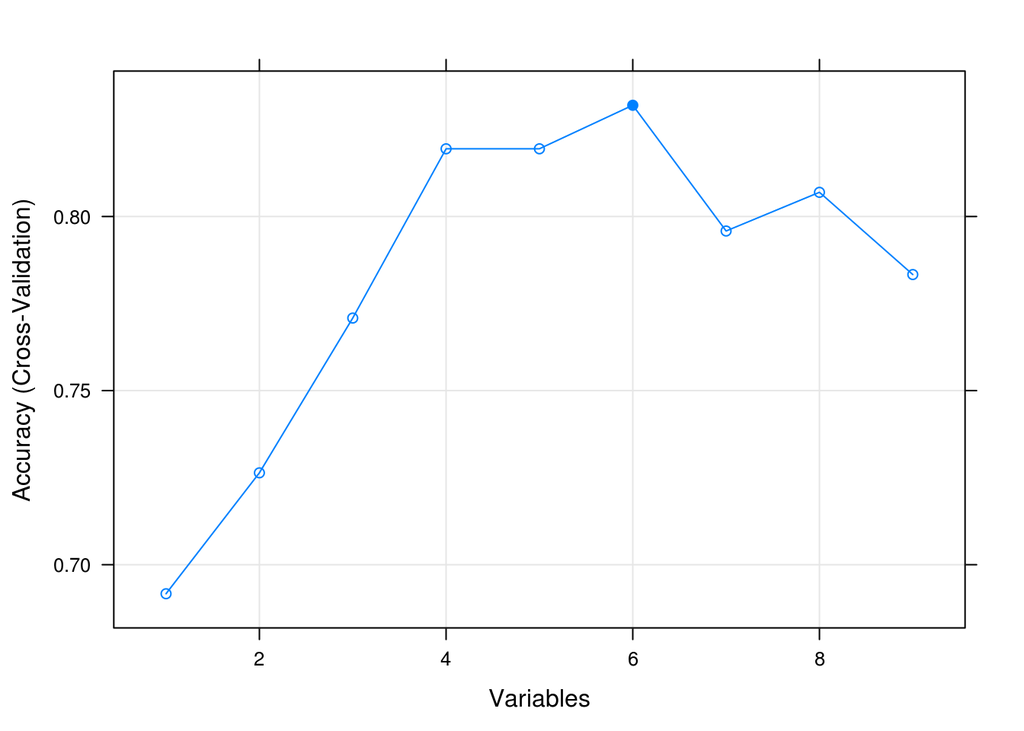

```r
# plot the results
plot(rf.results, type=c("g", "o"))
```

Результаты на обучающей

```r
rf.PredFS.train<-predict(rf.results$fit, glass.main, probability=FALSE)
confusionMatrix(rf.PredFS.train,glass.main$Type)
```

```
## Confusion Matrix and Statistics
##
##           Reference
## Prediction  1  2
##          1 44  0
##          2  0 44
##
##                Accuracy : 1
##                  95% CI : (0.9589, 1)
##     No Information Rate : 0.5
##     P-Value [Acc > NIR] : < 2.2e-16
##
##                   Kappa : 1
##  Mcnemar's Test P-Value : NA
##
##             Sensitivity : 1.0
##             Specificity : 1.0
##          Pos Pred Value : 1.0
##          Neg Pred Value : 1.0
##              Prevalence : 0.5
##          Detection Rate : 0.5
##    Detection Prevalence : 0.5
##       Balanced Accuracy : 1.0
##
##        'Positive' Class : 1
##
```

и тестовой выборках

```r
rf.PredFS.test<-predict(rf.results$fit, glass.test, probability=FALSE)
confusionMatrix(rf.PredFS.test,glass.test$Type)
```

```
## Confusion Matrix and Statistics
##
##           Reference
## Prediction  1  2
##          1 25  7
##          2  1 25
##
##                Accuracy : 0.8621
##                  95% CI : (0.7462, 0.9385)
##     No Information Rate : 0.5517
##     P-Value [Acc > NIR] : 4.688e-07
##
##                   Kappa : 0.7271
##  Mcnemar's Test P-Value : 0.0771
##
##             Sensitivity : 0.9615
##             Specificity : 0.7812
##          Pos Pred Value : 0.7813
##          Neg Pred Value : 0.9615
##              Prevalence : 0.4483
##          Detection Rate : 0.4310
##    Detection Prevalence : 0.5517
##       Balanced Accuracy : 0.8714
##
##        'Positive' Class : 1
##
```

**Ваша очередь:**

- Постройте регрессионые модели для данных о продаже (`Sales`) детских кресел

```r
library(ISLR)
data(Carseats)
```

```r
?Carseats
```

```r
pander::pandoc.table(head(Carseats), split.tables=Inf)
```

| Sales | CompPrice | Income | Advertising | Population | Price | ShelveLoc | Age | Education | Urban | US |
| --- | --- | --- | --- | --- | --- | --- | --- | --- | --- | --- |
| 9.5 | 138 | 73 | 11 | 276 | 120 | Bad | 42 | 17 | Yes | Yes |
| 11.22 | 111 | 48 | 16 | 260 | 83 | Good | 65 | 10 | Yes | Yes |
| 10.06 | 113 | 35 | 10 | 269 | 80 | Medium | 59 | 12 | Yes | Yes |
| 7.4 | 117 | 100 | 4 | 466 | 97 | Medium | 55 | 14 | Yes | Yes |
| 4.15 | 141 | 64 | 3 | 340 | 128 | Bad | 38 | 13 | Yes | No |
| 10.81 | 124 | 113 | 13 | 501 | 72 | Bad | 78 | 16 | No | Yes |

Для того, чтобы можно было посчитать корреляцию и чтобы функция `rfe()` работала, не выдавая ошибки “undefined column selected”, нужно преобразовать факторы в числа.

Для `Urban` и `US` (yes-no questions):

```r
Carseats$Urban <- as.numeric(Carseats$Urban) - 1
Carseats$US <- as.numeric(Carseats$US) - 1
```

Для `ShelveLoc` (фактор с тремя вариантами):

1 способ (не всегда подходящий)

```r
Carseats$ShelveLocNew <- as.numeric(Carseats$ShelveLoc)
```

2 способ (dummy variables)

```r
temp <- model.matrix(~ ShelveLoc - 1, data=Carseats)
head(temp)
```

```
##   ShelveLocBad ShelveLocGood ShelveLocMedium
## 1            1             0               0
## 2            0             1               0
## 3            0             0               1
## 4            0             0               1
## 5            1             0               0
## 6            1             0               0
```

```r
Carseats <- dplyr::select(Carseats, -ShelveLoc)
Carseats <- cbind(Carseats, temp)
```

- Какая модель дает лучшее предсказание на тестовой выборке? Какие предикторы в нее входят?